# R Notebook

# Load Libraries

```r
library(tidyverse)
library(tidymodels)
library(tidytext)
library(lubridate)
library(scales)
library(janitor)
library(tictoc)
library(future)
library(doFuture)
library(tidyquant)
library(leaflet)

registerDoFuture()

n_cores <- parallel::detectCores()

plan(strategy = cluster,
     workers  = parallel::makeCluster(n_cores))
```

# Prepare Data

```r
ml_data <- read_rds("ms_tbl_updated_geo_locs.rds")

ml_prep <- ml_data %>%
    rename("GeoLocation" = geo_data) %>%
    mutate(temp = GeoLocation,
           temp = str_remove_all(temp, "Geolocation: "),
           number_casualties = number_killed + number_injured) %>%
    separate(temp, into = c("latitude","longitude"), sep = ", ") %>%
    mutate(across(latitude:longitude, ~ as.numeric(.)),
           city_or_county = str_trim(str_remove_all(city_or_county, "\\(.*\\)")))
```

# Filter Down to One State and Process EDA

Time is certainly a variable with mass shootings in Illinois, and we don’t want date or year to play a role in the model because ideally we want to help identify when and where a mass shooting incident might occur given some inputs, but looking back in time isn’t helpful here.

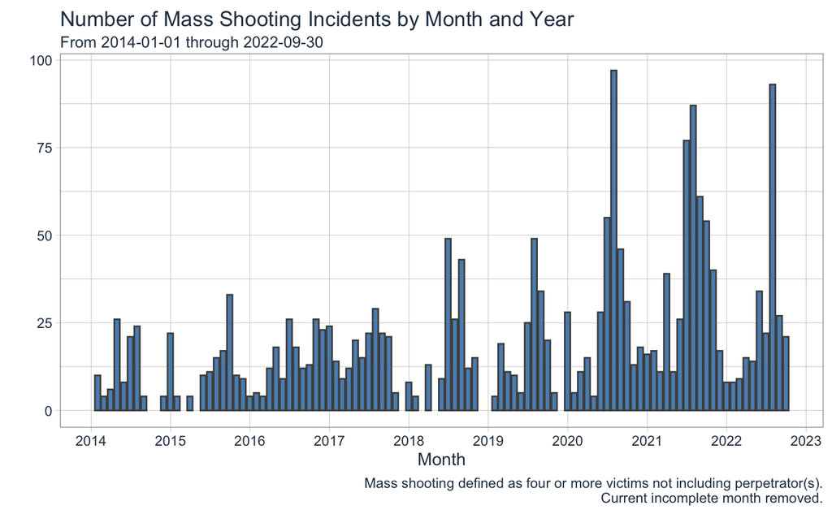

Let’s try looking at 2020 forward in the “new normal” range. I think this looks better and it mitigates the impact of time somewhat on the variability of the data year over year.

[figure not shown]

# Feature Selection and EDA

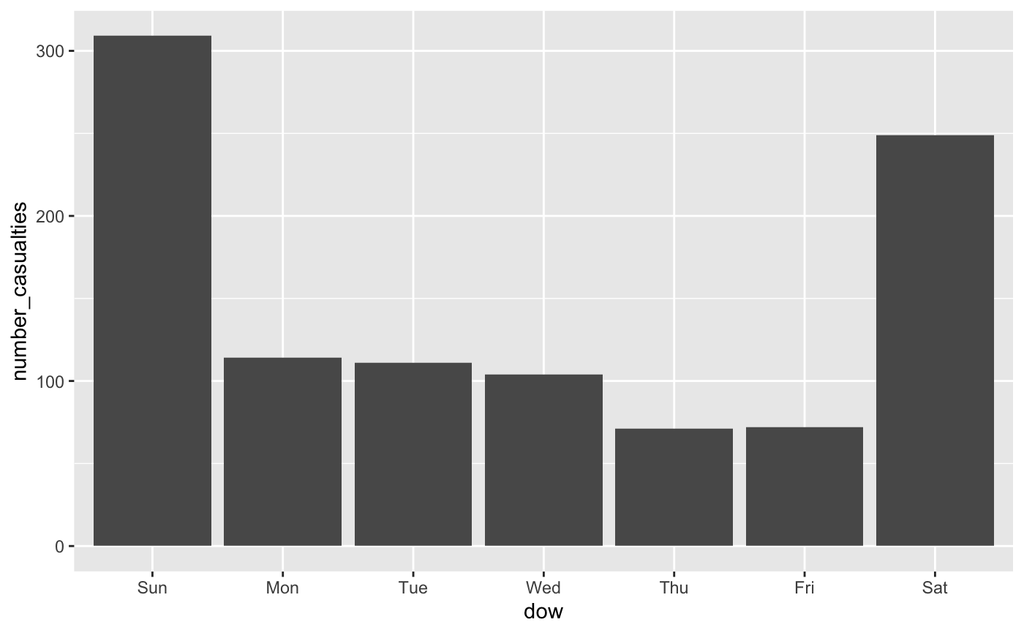

The majority of mass shootings occur in the Chicago area with outliers throughout the state.

```r
ml_illinois %>%
    leaflet(height = 1000, width = 1000) %>%
    addProviderTiles("Stamen.Toner") %>%
    addCircleMarkers(radius = 3, color = "blue", clusterOptions = markerClusterOptions()) %>%
    setView(lng = -87, lat = 35,  zoom = 6)
```

```
Assuming "longitude" and "latitude" are longitude and latitude, respectively
```

[interactive chart not shown]

# The Question - Given the time and locaiton data we have, can we provide insights into when and where mass shootings might occur? Would this prediction be helpful to police and communities in an effort to prevent these events from happening? Let’s start with a tree based model and see what that yields.

| incident_id | state | city_or_county | latitude | longitude | number_casualties |
| --- | --- | --- | --- | --- | --- |
| 1598447 | Illinois | Chicago | 41.8845 | -87.7260 | 5 |
| 1621821 | Illinois | Chicago | 41.7764 | -87.6159 | 6 |
| 1629042 | Illinois | Chicago | 41.7516 | -87.5941 | 5 |
| 1635411 | Illinois | Chicago | 41.7513 | -87.6028 | 7 |
| 1654341 | Illinois | Chicago | 41.7376 | -87.6728 | 4 |
| 1671078 | Illinois | Chicago | 41.8644 | -87.7178 | 5 |
| 1686685 | Illinois | Chicago | 41.8669 | -87.7233 | 4 |
| 1688917 | Illinois | Chicago | 41.8819 | -87.7208 | 4 |
| 1695645 | Illinois | Chicago | 41.7424 | -87.5615 | 4 |
| 1698987 | Illinois | Chicago | 41.8805 | -87.6778 | 4 |

[output cut: 138 more lines]

# Split Data into Training and Testing Sets with Additional Cross-Fold Validation

```r
illinois_split <- ml_chicago %>%
    initial_split(prop = 0.8, strata = c(month, dow))
```

[output not shown]

# Create a Tree-Based Tidymodels ML Recipe

```r
illinois_tree_recipe <-
    recipe(number_casualties ~ ., data = illinois_train) %>%
    update_role(incident_id, new_role = "id") %>%
    update_role(state, new_role = "id") %>%
    update_role(city_or_county, new_role = "id") %>%
    step_other(month, threshold = 0.05) %>%
    step_dummy(all_nominal_predictors())

illinois_tree_recipe %>%
    prep() %>%
    bake(new_data = illinois_train)
```

[output not shown]

```r
xgboost_spec <- boost_tree(trees = tune(), min_n = tune(), tree_depth = tune(), learn_rate = tune()) %>%
    set_engine("xgboost") %>%
    set_mode("regression")

xgboost_workflow <- workflow() %>%
    add_recipe(illinois_tree_recipe) %>%
    add_model(xgboost_spec)

set.seed(1984)

xg_tune_grid <- grid_random(trees(), min_n(), tree_depth(), learn_rate(), size = 10)

xgboost_tune <- tune_grid(xgboost_workflow, resamples = illinois_vfolds, grid = xg_tune_grid)

xgboost_tune %>% show_best()

best_xg <- xgboost_tune %>%
    select_best(metric = "rmse")

final_xg_workflow <- xgboost_workflow %>%
    finalize_workflow(best_xg)

xg_wf_fit <- final_xg_workflow %>%
             fit(data = illinois_train)

xg_fit <- xg_wf_fit %>%
    extract_fit_parsnip()

vip::vip(xg_fit)
```

[output not shown]